# MDS Data Science Portfolio

Mitchell D. Shuey

# Demonstration 1: Data Cleaning, Qualitative Analysis

### MediaMonitor: Collection methodology

In this dataset, headlines were compiled from a specific list of sources with the keyword “Brazil” since the prior business day of collection. Sports matters were omitted, with an emphasis on collecting news regarding the state of Brazil and its economy, society, and politics, categorized as *pillars*. From there, a *topic* if applicable further delved into relevant subcategories such as agriculture, technology, energy, etc.

This data was compiled between the beginning of the 2017 calendar year and the end of November. There were 222 days of headline collection during this time period, with 2045 total headlines. Of particular interest, a subjective qualitative variable *impact* was also given with each observation: Labelling a positive, negative, or neutral impact on a potential reader:

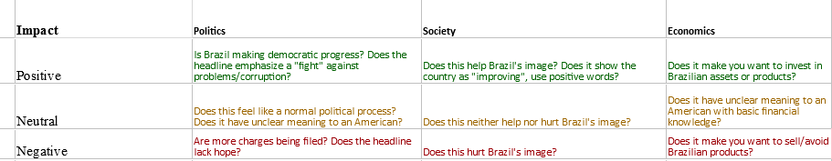

```r
#Data has been read in under the variable name "medmon"
library(plyr)
library(readxl)
#tidying, establishing the correct variable types:
medmon$Sources = as.factor(medmon$Sources)
medmon$Pillar = as.factor(medmon$Pillar)
medmon$Topic = as.factor(medmon$Topic)
medmon$Impact = as.factor(medmon$Impact)
medmon$Date = as.Date(medmon$Date, origin="1900-01-01")
tail(medmon)
```

| Title | Sources | Date | Pillar | Topic | Impact | X__1 |
| --- | --- | --- | --- | --- | --- | --- |
| Goldman Sees Iron Ore Sinking Back to $50 | Bloomberg | 2017-11-29 | Economy | NA | Neutral | NA |
| Asian groups vie for stake in southern Brazil railroad -source | Reuters | 2017-11-29 | Economy | Infrastructure | Positive | NA |
| - Brazil posts larger-than-expected budget surplus in October | Reuters | 2017-11-29 | Economy | NA | Positive | NA |
| - Plan to help Brazil's Caixa with FGTS funds under scrutiny –media | Reuters | 2017-11-29 | Economy | NA | Neutral | NA |
| - Brazil lower house passes bill aimed at boosting biofuels use | Reuters | 2017-11-29 | Politics | Green Economy and Energy | Positive | NA |
| - Brazil Senate approves creation of mining regulatory agency | Reuters | 2017-11-29 | Economy | Politics | Positive | NA |

```r
#From here, the goal is to get a daily count for _impact_.
library(plyr)
counter = count(medmon$Date)

mm_pos= subset(medmon, Impact == "Positive")
mm_neg= subset(medmon, Impact == "Negative")
c_pos = count(mm_pos$Date)
c_neg = count(mm_neg$Date)
counter = merge(counter, c_pos, by="x", all=TRUE)
counter = merge(counter, c_neg, by="x", all=TRUE)
colnames(counter)= c("Date","Total","Pos","Neg")

head(counter)
```

|  | Date | Total | Pos | Neg |
| --- | --- | --- | --- | --- |
| 1 | 2017-01-05 | 14 | 3 | 7 |
| 2 | 2017-01-06 | 11 | 1 | 7 |
| 3 | 2017-01-09 | 9 | NA | 3 |
| 4 | 2017-01-10 | 6 | 4 | 1 |
| 5 | 2017-01-11 | 12 | 5 | 2 |
| 6 | 2017-01-12 | 10 | 3 | 3 |

We have the initial structure now, but we need to retain counts of “0” for when we begin graphing. Then and only then we can subtract from our Total column to get the final Neutral column:

```r
counter[is.na(counter)] = 0
counter$Neu = counter$Total - counter$Pos - counter$Neg
head(counter)
```

|  | Date | Total | Pos | Neg | Neu |
| --- | --- | --- | --- | --- | --- |
| 1 | 2017-01-05 | 14 | 3 | 7 | 4 |
| 2 | 2017-01-06 | 11 | 1 | 7 | 3 |
| 3 | 2017-01-09 | 9 | 0 | 3 | 6 |
| 4 | 2017-01-10 | 6 | 4 | 1 | 1 |
| 5 | 2017-01-11 | 12 | 5 | 2 | 5 |
| 6 | 2017-01-12 | 10 | 3 | 3 | 4 |

## Visualization

I began without using ggplot. I manually added tick marks for each month; Although there may have been a way to code this, I called upon Occam’s razor and found the 11 observations where the month changed.

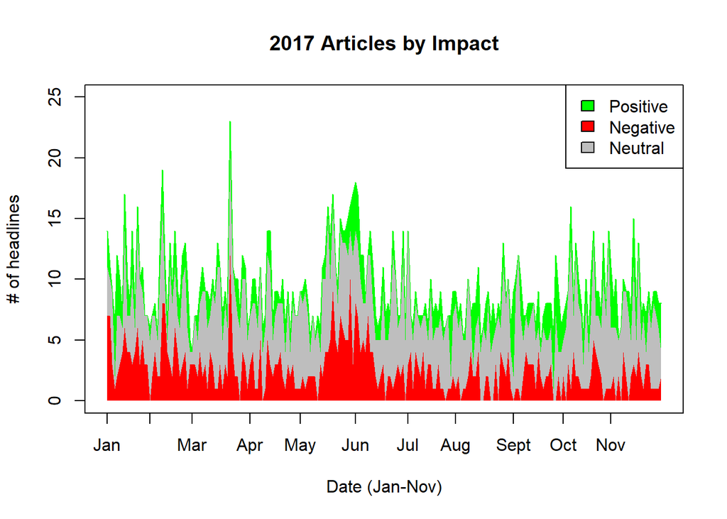

```r
c_cols = c("Black", "Black", "Green", "Red", "Gray")
plot.ts(counter$Total, ylim= c(0, 25), col="Green",
        xaxt= "n", ylab="# of headlines", xlab= "Date (Jan-Nov)")
    title(main= "2017 Articles by Impact")
    axis(1, at=c(1, 18, 35, 58, 78, 100, 121, 140, 163, 183, 202), labels = c("Jan","Feb","Mar","Apr", "May", "Jun", "Jul","Aug","Sept","Oct", "Nov"))
#We begin plotting by stacking each layer with an appropriate color label
    polygon(x=c(1:222, 222:1), border = NA, y=c(counter$Total, rev(counter$Neg+counter$Neu)), col= "Green")
    polygon(x=c(1:222, 222:1), border = NA, y=c((counter$Neg + counter$Neu), rev(counter$Neg)), col= "Grey")
    polygon(x=c(1:222, 222:1), border = NA, y=c((counter$Neg), rep(0, times=222)), col= "Red")
    legend("topright", c("Positive", "Negative", "Neutral"), fill = c("Green", "Red", "Gray"))
```

Already we can see some interesting trends we will want to explore. From here we will switch to the more efficient code of ggplot. To make trends more visible to humans, we’re going to bin data by the week:

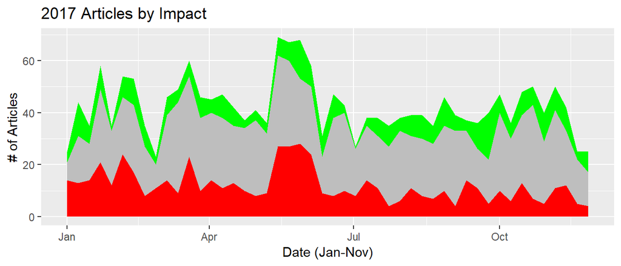

```r
#Preparing the weekly sums
counter$DateW=as.Date(cut.Date(counter$Date, breaks="week", start.on.monday = F))
counterW=aggregate(cbind(counter$Total, counter$Pos, counter$Neg, counter$Neu)~DateW,data=counter,FUN = sum)
colnames(counterW)=c("DateW", "Total", "Pos", "Neg", "Neu")
#Plotting begins
g1=ggplot(data=counterW, aes(x=DateW, y=Total)) +
  geom_ribbon(aes(ymin=0, ymax=counterW$Neg),fill="red")+
  geom_ribbon(aes(ymin=counterW$Neg, ymax=(counterW$Neg+counterW$Neu)), fill="gray") +
  geom_ribbon(aes(ymin=(counterW$Total-counterW$Pos), ymax=counterW$Total), fill = "green") +
  labs(title="2017 Articles by Impact", x="Date (Jan-Nov)", y="# of Articles")

#Percentage of totals:

counterW$posp=counterW$Pos/counterW$Total
counterW$negp=counterW$Neg/counterW$Total
counterW$neup=counterW$Neu/counterW$Total
#Plotting continues
g2=ggplot(data=counterW, aes(x=DateW, y=1)) +
  geom_ribbon(aes(ymin=0, ymax=counterW$negp),fill="red")+
  geom_ribbon(aes(ymin=counterW$negp, ymax=(counterW$neg+counterW$neup)), fill="gray", alpha=0.7) +
  geom_ribbon(aes(ymin=(1-counterW$posp), ymax=1), fill = "green") +
  labs(title="2017 Articles by Impact (Percentage)", x="Date (Jan-Nov)", y="% of Articles")
g1
```

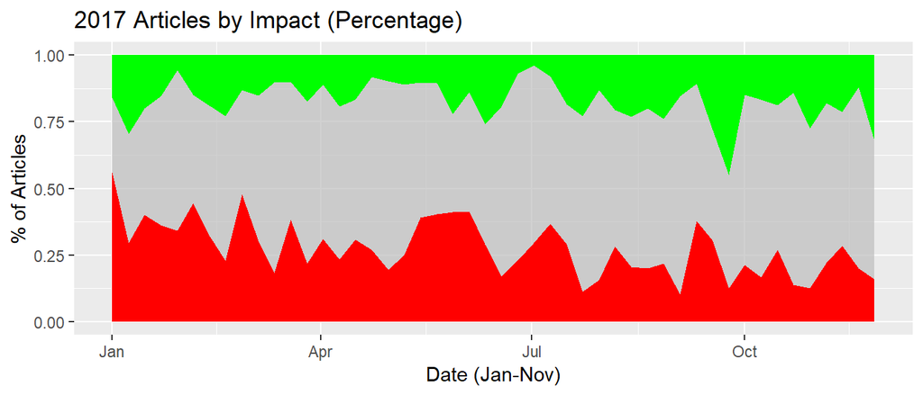

```r
g2
```

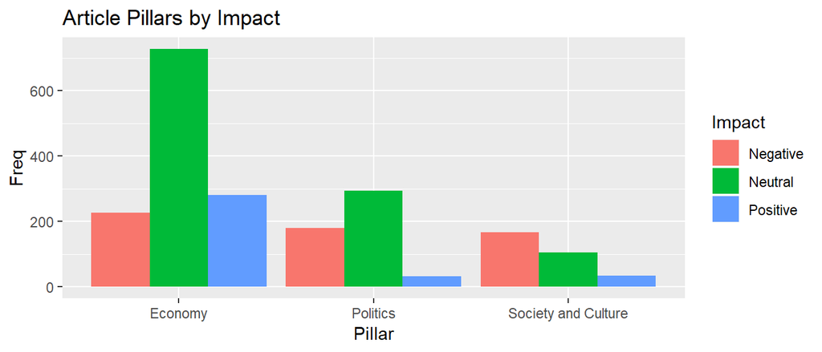

```r
#Qualitative factor breakdown
pill.imp = table(medmon$Pillar, by=medmon$Impact)
pill.imp=as.data.frame(pill.imp)
colnames(pill.imp)= c( "Pillar", "Impact", "Freq")
ggplot(pill.imp, aes(Pillar, Freq, fill=Impact))+geom_bar(stat="identity", position = position_dodge()) +labs(title ="Article Pillars by Impact")
```

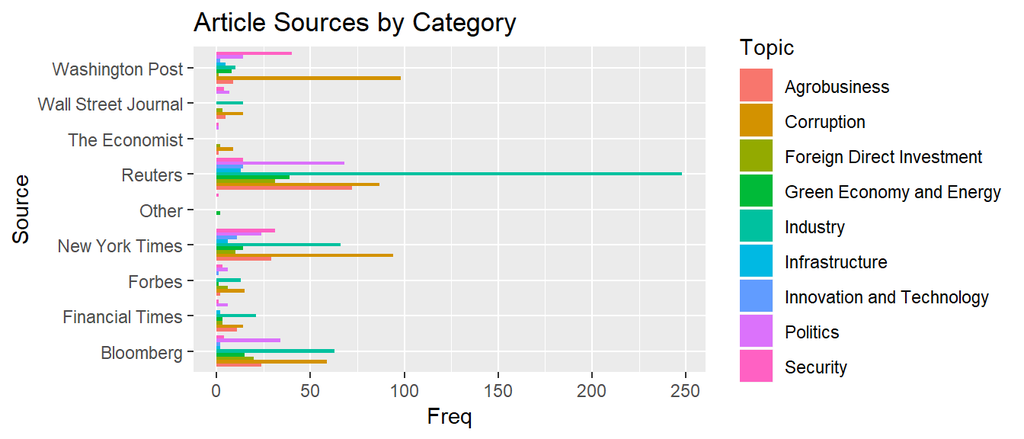

```r
#A list of sources by categorized topic

source.top = table(medmon$Sources, by=medmon$Topic)
source.top = as.data.frame(source.top[])
colnames(source.top) = c("Source", "Topic", "Freq")
ggplot(source.top, aes(Source, Freq, fill=Topic))+geom_bar(stat="identity", position = position_dodge())+ coord_flip()+labs(title="Article Sources by Category")
```

As we can see, there are some stark differences in the number of articles involving our subject country within each media source.

## Text Mining

Let’s say we were now interested in finding the most frequent words within headlines of the year.

```r
library(tm)
library(SnowballC)
library(data.table)
```

```r
corp=medmon$Title
corpstring=paste(corp,collapse = "", sep = " ")
corpstring= VectorSource(corpstring)
corp=VCorpus(corpstring )

#Transformations to isolate the key root words of each headline
corp=tm_map(corp, removePunctuation)
corp=tm_map(corp, content_transformer(tolower))
corp=tm_map(corp, removeWords, stopwords("english"))
corp=tm_map(corp, stemDocument)
matrix=DocumentTermMatrix(corp)
#Determining most common word stems
wordfreq = findMostFreqTerms(matrix, 100)
wordfreq=wordfreq$`1`
wordfreq=as.data.frame(wordfreq)
wordfreq=setDT(wordfreq, keep.rownames=T)
head(wordfreq, 25)
```

| rn | wordfreq |
| --- | --- |
| brazil | 456 |
| say | 152 |
| temer | 122 |
| presid | 76 |
| new | 73 |
| brazilian | 71 |
| court | 66 |
| pension | 65 |
| corrupt | 63 |
| reform | 63 |

[output cut: 15 more lines]

From here we can filter keywords and find the key terms readers have seen with their news over the year. These are simple examples of the insight that can be gained from such data; Much more robust collection methods can lead to an even fuller picture of a country’s portrayal in the media.